# Assignment 2: Portfolio Optimisation using GA

Benedikt Mueller (201973906)

18/02/2020

# Load libraries

Load packages required to run the code (note: there might be packages that require other packages and specific versions of packages. So if there occurs an error it is most likely due to the aforementioned issue. Defining max_iteration for each GA:

```r
suppressPackageStartupMessages(library("quantmod"))
suppressPackageStartupMessages(library("GA"))
suppressPackageStartupMessages(library("rvest"))
#suppressPackageStartupMessages(library("ggpubr"))
suppressPackageStartupMessages(library("tidyquant"))
suppressPackageStartupMessages(library("fPortfolio"))
#suppressPackageStartupMessages(library("PerformanceAnalytics"))
suppressPackageStartupMessages(library("dplyr"))
suppressPackageStartupMessages(library("xts"))
suppressPackageStartupMessages(library("knitr"))
options(warn=-1) #turn warining off

max_iteration = 1000 #change value of iters per GA
```

# Stock data

Using “tq_index()” from “tidyquant” to get stock tickers of Stock Enviornment (here DOW):

```r
#get stock inf of DOW stocks
getStocks = tq_index("DOW") %>% as.data.frame()
```

```
## Getting holdings for DOW
```

```r
getStocks = subset(getStocks,symbol!="DOW")  # delete rows with no stock data for period --> "DOW"
myStocks = gsub(pattern = '\\.', '-', getStocks$symbol) # change: BRK.B -> BRK-B (yahoo uses '-')
orgWeights = getStocks$weight/sum(getStocks$weight) # get initial weightings - with rebalancing
head(getStocks)
```

```
##   symbol                         company identifier   sedol     weight
## 1     BA                  Boeing Company   09702310 2108601 0.07728540
## 2   AAPL                      Apple Inc.   03783310 2046251 0.07323140
## 3    UNH UnitedHealth Group Incorporated   91324P10 2917766 0.07051316
## 4     HD                 Home Depot Inc.   43707610 2434209 0.05739210
## 5     GS        Goldman Sachs Group Inc.   38141G10 2407966 0.05394866
## 6    MCD          McDonald's Corporation   58013510 2550707 0.05049821
##                   sector shares_held local_currency
## 1            Industrials     5375867            USD
## 2 Information Technology     5375867            USD
## 3            Health Care     5375867            USD
## 4 Consumer Discretionary     5375867            USD
## 5             Financials     5375867            USD
## 6 Consumer Discretionary     5375867            USD
```

Call the function stock_data to get weekly returns of each stock in index from quantmod getSymbols and weeklyReturn (from 2015-01-01 to date). Split data in total, future (test) and train datasets (80% to 20%). The data was not tested of suitableness (e.g. normality) or log-transformed.

```r
stock_data = function(StartP,EndP) {
Stocks = lapply(myStocks, function(sym) {
  weeklyReturn(na.omit(getSymbols(sym, from=StartP, to=EndP, auto.assign=FALSE)))
})
return(Stocks)
}

Stocks = stock_data(StartP = "2015-01-01",EndP = Sys.Date())
```

[output not shown]

```r
myDataTotal = do.call(merge.xts, Stocks)
myDataTotal = as.data.frame(myDataTotal, col.names = myStocks); names(myDataTotal) = c(myStocks)
myDataTotal = myDataTotal[sapply(myDataTotal, function(myDataTotal) !any(is.na(myDataTotal)))]

#create two datasets: train and test, define ratio
nrows = length(myDataTotal[,1])-round(length(myDataTotal[,1])*0.20,0)
myDataFuture = myDataTotal[-c(1:nrows),]
myData = myDataTotal[c(1:nrows),]
```

# Setup of functions

Define the portfolio returns, using vectorial multiplication to enhance runtime. Returns as vectors allows plotting of results. Sharpe ratio as objective to realize the portfolio optimazation: (Note: We do not assume a risk free rate, so return of portfolio = excess return)

```r
portReturns = function(x,myData) {
  myReturns = 0
  for (i in 1:length(x)) {
    myReturns = myReturns + myData[,i] * x[i]
  }
  return(myReturns)
}

portRisk = function(x,myData) {
    myRisk = sqrt(t(x) %*% cov(myData) %*% x)
  return(myRisk)
}


sharpe = function(x) {
  myReturns = portReturns(x,myData = myData)
  myRisk = portRisk(x,myData = myData)
  return(sum(myReturns)/myRisk)
}
```

# Sharpe Optimisation

Define the fitness function which calls sharpe ratio (return&risk) function. Normalize weights before handing over to the other functions. GA settings resulted in the most stable returns. Boundaries do not allow short selling (restricted from 0-1)..

```r
# sharpe optimisation
objSharpe = function(x) {
    x = x/sum(x)
    return(sharpe(x=x))
    #return (-sharpe(x=x) + 100*(sum(x != 0.00)/length(x))) #penalizing larger portfolios, did not work out as expected.
}


GA = ga(type="real-valued", fitness = objSharpe ,lower = rep(0,ncol(myData)), upper = rep(1,ncol(myData)),
        popSize=150,pmutation=1/ncol(myData),pcrossover = 0.8,maxiter = max_iteration, run=200,
        parallel=T, monitor=F, seed = 1)

#plot(GA)
summary(GA)
```

```
## -- Genetic Algorithm -------------------
##
## GA settings:
## Type                  =  real-valued
## Population size       =  150
## Number of generations =  1000
## Elitism               =  8
## Crossover probability =  0.8
## Mutation probability  =  0.03448276
## Search domain =
##       x1 x2 x3 x4 x5 x6 x7 x8 x9 x10  ...  x28 x29
## lower  0  0  0  0  0  0  0  0  0   0         0   0
## upper  1  1  1  1  1  1  1  1  1   1         1   1
##
## GA results:
## Iterations             = 1000
## Fitness function value = 44.36869
## Solution =
##            x1         x2        x3         x4         x5        x6        x7
## [1,] 0.954286 0.02695728 0.9380078 0.03156511 0.03018613 0.9378844 0.8122478
##             x8         x9        x10  ...       x28       x29
## [1,] 0.4175019 0.02860531 0.01209081       0.049784 0.0118499
```

..with GA summary output and optimal weights:

```r
normalWeights = summary(GA)$solution/sum(summary(GA)$solution)
optiWeights = as.vector(normalWeights)
TableoptiWeights = as.data.frame(cbind(names(myData),round(optiWeights,4)))
names(TableoptiWeights) = c("Ticker","Weight")
TableoptiWeights
```

```
##    Ticker Weight
## 1      BA 0.1891
## 2    AAPL 0.0053
## 3     UNH 0.1859
## 4      HD 0.0063
## 5      GS  0.006
## 6     MCD 0.1858
## 7       V 0.1609
## 8    MSFT 0.0827
## 9     MMM 0.0057
## 10    UTX 0.0024
## 11    JNJ 0.0046
## 12    IBM 0.0025
## 13    DIS 0.0032
## 14    CAT 0.0081
## 15    JPM 0.0045
## 16    TRV 0.0099
## 17    AXP 0.0085
## 18     PG 0.0114
## 19    WMT 0.0101
## 20    CVX 0.0015
## 21    NKE 0.0512
## 22    MRK 0.0133
## 23   INTC  0.009
## 24     KO 0.0055
## 25    XOM  0.005
## 26     VZ 0.0064
## 27    WBA  0.003
## 28   CSCO 0.0099
## 29    PFE 0.0023
```

## Plots of different returns

Create random portfolio combinations and index, balanced portfolios from train dataset. Plot returns to evaluate whether the initial GA-optimised portfolio can outperform on train data…:

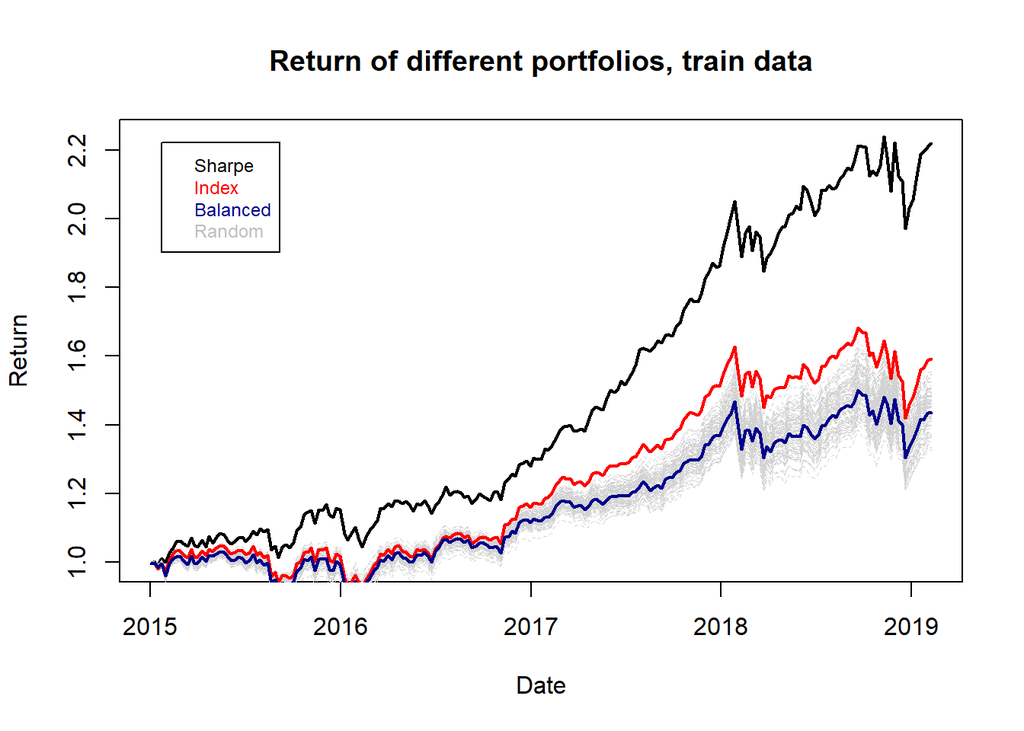

```r
# create randomised portfolios
randReturnsFunc = function(x,myData) {
  myRands = list()
  for (i in 1:x){
    xRand = runif(length(myData), min=0, max=1)
    xRand = xRand/sum(xRand)
    myRands[[i]] = 1 + portReturns(x = xRand, myData = myData)
  }
  return(myRands)
}
#randReturns = randReturnsFunc(x=1000)

# optimised, original (index) and balanced (all equally) weighted Returns
optiReturns = 1 + portReturns(optiWeights,myData = myData)

orgReturns = 1 + portReturns(orgWeights,myData = myData)

balWeights = rep(1/length(myData),ncol(myData))
balReturns = 1 + portReturns(balWeights,myData = myData)

# create plot
plot(as.Date(rownames(myData)),cumprod(optiReturns),type="l",lwd=2, col="black",
     xlab="Date",ylab="Return",main="Return of different portfolios, train data")
for(i in 1:length(randReturnsFunc(x=100,myData=myData))) lines(as.Date(rownames(myData)),
                                                                cumprod(randReturnsFunc(x=100,myData=myData)[[i]]),
                                                                col = "lightgrey", lwd=0.5, lty  = "dashed")
lines(as.Date(rownames(myData)),cumprod(orgReturns),type="l",lwd=2, col="red")
lines(as.Date(rownames(myData)),cumprod(balReturns),type="l",lwd=2, col="darkblue")
legend("topleft",inset = .05,legend = c("Sharpe","Index","Balanced","Random"),
       text.col = c("black","red","darkblue","grey"),cex=0.75)
```

..and test data:

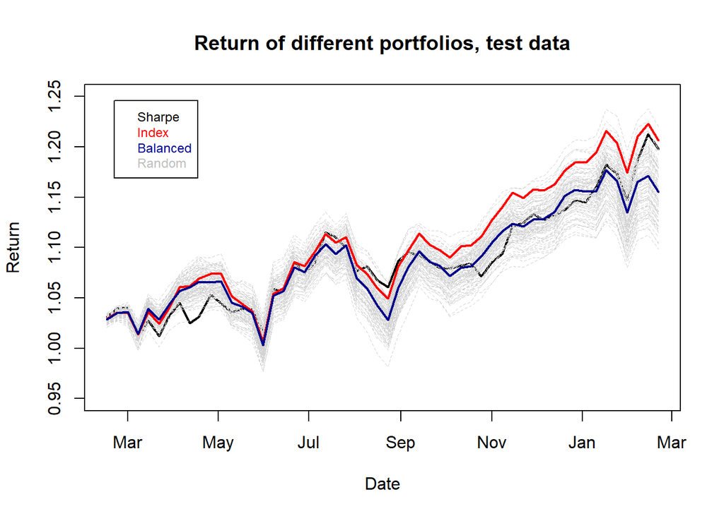

```r
plot(as.Date(rownames(myDataFuture)),cumprod(1 + portReturns(optiWeights,myData = myDataFuture)),type="l",lwd=2, col="black",
     xlab="Date",ylab="Return",main="Return of different portfolios, test data", ylim= c(0.95,1.25))
for(i in 1:length(randReturnsFunc(x=100,myData=myDataFuture))) lines(as.Date(rownames(myDataFuture)),
                                                                cumprod(randReturnsFunc(x=100,myData=myDataFuture)[[i]]),
                                                                col = "lightgrey", lwd=0.5, lty  = "dashed")
lines(as.Date(rownames(myDataFuture)),cumprod(1 + portReturns(orgWeights,myData = myDataFuture)),type="l",lwd=2, col="red")
lines(as.Date(rownames(myDataFuture)),cumprod(1 + portReturns(balWeights,myData = myDataFuture)),type="l",lwd=2, col="darkblue")
legend("topleft",inset = .05,legend = c("Sharpe","Index","Balanced","Random"),
       text.col = c("black","red","darkblue","grey"),cex=0.75)
```

Evaluating the train data graphs reveals that the Sharpe PF outperforms every other selected PF (100 radomized, evenly balanced and index) by far. Not a single entity of the 100 (or even if tested with 1000) could outperform the optimized Ga-weighted PF. However, when testing on unseen data, the sharpe and index leveling off at almost the same return and some of the random PFs does indeed outperform the optimized ga PF. But since we are talking about prediction it is hard to tell whether this is caused due to a insufficient weighting or rather due to the “wrong” test period. In conclusion, the ga optimisation does what it should do: optimizing the weights given the train dataset.

# Minimun risk and max return optimisation

Now building min variance and max return with GA. Change objective function therefore (note: min var requires to define the problem as a negative maximation, ergo add minus sign):

```r
##### min var optimisation
objMin = function(x) {
  x = x/sum(x)
  return(sum(portRisk(x=x,myData = myData)))
  #return (-sharpe(x=x) + 100*(sum(x != 0.00)/length(x))) #penalizing larger portfolios
}

GAmin = ga(type="real-valued", function(x)-objMin(x),lower = rep(0,ncol(myData)), upper = rep(1,ncol(myData)),
        popSize=150,pmutation=1/ncol(myData),pcrossover = 0.8,maxiter = max_iteration, run=200,
        parallel=T, monitor=F, seed = 1)
summary(GAmin)
```

```
## -- Genetic Algorithm -------------------
##
## GA settings:
## Type                  =  real-valued
## Population size       =  150
## Number of generations =  1000
## Elitism               =  8
## Crossover probability =  0.8
## Mutation probability  =  0.03448276
## Search domain =
##       x1 x2 x3 x4 x5 x6 x7 x8 x9 x10  ...  x28 x29
## lower  0  0  0  0  0  0  0  0  0   0         0   0
## upper  1  1  1  1  1  1  1  1  1   1         1   1
##
## GA results:
## Iterations             = 1000
## Fitness function value = -0.01540567
## Solution =
##              x1         x2        x3         x4         x5        x6        x7
## [1,] 0.01488868 0.04945215 0.1144238 0.02196442 0.01824395 0.9598927 0.2150944
##             x8         x9        x10  ...          x28       x29
## [1,] 0.0286288 0.02662539 0.02810723       0.004714738 0.1304147
```

```r
normalWeights = summary(GAmin)$solution/sum(summary(GAmin)$solution)
minWeights = as.vector(normalWeights)
minReturns = 1 + portReturns(minWeights,myData = myData)


##### max return optimisation
objMax = function(x) {
  x = x/sum(x)
  return(sum(portReturns(x=x,myData = myData)))
  #return (-sharpe(x=x) + 100*(sum(x != 0.00)/length(x))) #penalizing larger portfolios
}

GAmax = ga(type="real-valued", fitness = objMax ,lower = rep(0,ncol(myData)), upper = rep(1,ncol(myData)),
        popSize=150,pmutation=1/ncol(myData),pcrossover = 0.8,maxiter = max_iteration, run=200,
        parallel=T, monitor=F, seed = 1)
summary(GAmax)
```

```
## -- Genetic Algorithm -------------------
##
## GA settings:
## Type                  =  real-valued
## Population size       =  150
## Number of generations =  1000
## Elitism               =  8
## Crossover probability =  0.8
## Mutation probability  =  0.03448276
## Search domain =
##       x1 x2 x3 x4 x5 x6 x7 x8 x9 x10  ...  x28 x29
## lower  0  0  0  0  0  0  0  0  0   0         0   0
## upper  1  1  1  1  1  1  1  1  1   1         1   1
##
## GA results:
## Iterations             = 1000
## Fitness function value = 0.8946874
## Solution =
##             x1         x2        x3         x4         x5         x6      x7
## [1,] 0.9502598 0.04068226 0.9222939 0.05020666 0.02751786 0.04772988 0.16167
##             x8        x9        x10  ...         x28       x29
## [1,] 0.8698949 0.0403482 0.01668988       0.04736267 0.0118499
```

```r
normalWeights = summary(GAmax)$solution/sum(summary(GAmax)$solution)
maxWeights = as.vector(normalWeights)
maxReturns = 1 + portReturns(maxWeights,myData = myData)
```

## Plots of different returns

Evaluate performance, train data..:

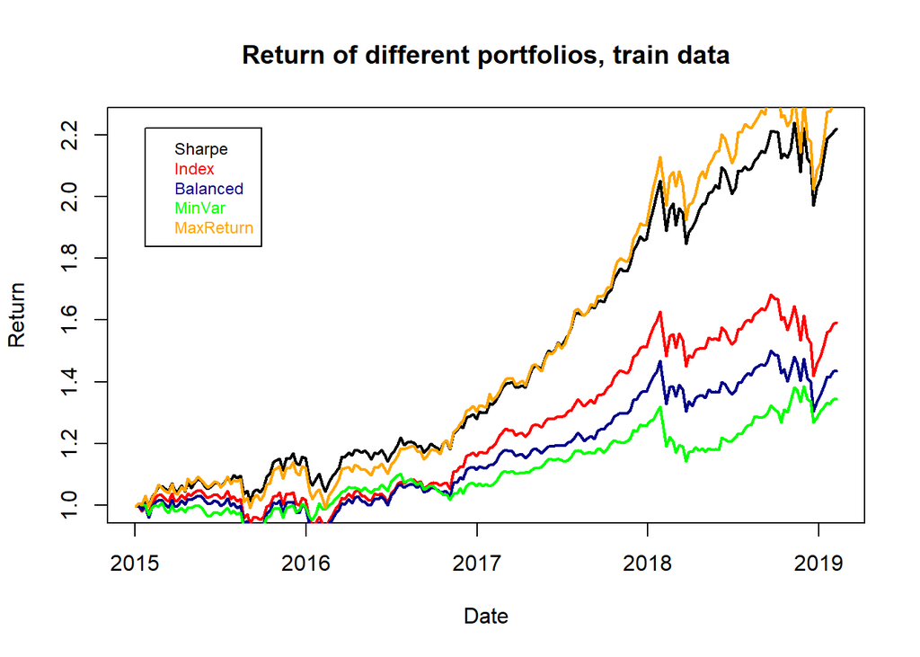

```r
# plot different portfolios
plot(as.Date(rownames(myData)),cumprod(optiReturns),type="l",lwd=2, col="black",
     xlab="Date",ylab="Return",main="Return of different portfolios, train data")
lines(as.Date(rownames(myData)),cumprod(orgReturns),type="l",lwd=2, col="red")
lines(as.Date(rownames(myData)),cumprod(balReturns),type="l",lwd=2, col="darkblue")
lines(as.Date(rownames(myData)),cumprod(minReturns),type="l",lwd=2, col="green")
lines(as.Date(rownames(myData)),cumprod(maxReturns),type="l",lwd=2, col="orange")
legend("topleft",inset = .05,legend = c("Sharpe","Index","Balanced","MinVar","MaxReturn"),
       text.col = c("black","red","darkblue","green","orange"),cex=0.75)
```

…Test data..:

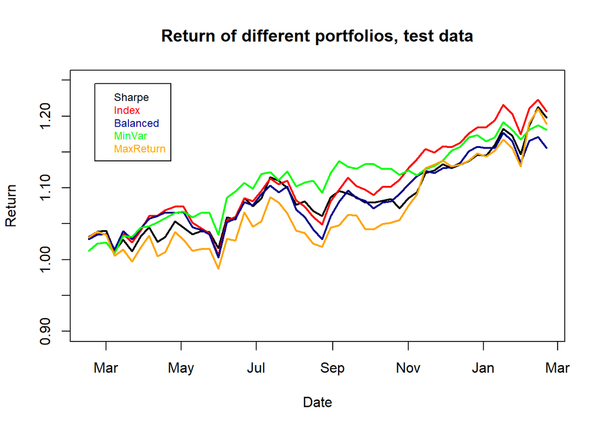

```r
# test dataset
plot(as.Date(rownames(myDataFuture)),cumprod(1 + portReturns(optiWeights,myData = myDataFuture)),type="l",lwd=2, col="black",
     xlab="Date",ylab="Return",main="Return of different portfolios, test data",ylim=c(0.90,1.25))
lines(as.Date(rownames(myDataFuture)),cumprod(1 + portReturns(orgWeights,myData = myDataFuture)),type="l",lwd=2, col="red")
lines(as.Date(rownames(myDataFuture)),cumprod(1 + portReturns(balWeights,myData = myDataFuture)),type="l",lwd=2, col="darkblue")
lines(as.Date(rownames(myDataFuture)),cumprod(1 + portReturns(minWeights,myData = myDataFuture)),type="l",lwd=2, col="green")
lines(as.Date(rownames(myDataFuture)),cumprod(1 + portReturns(maxWeights,myData = myDataFuture)),type="l",lwd=2, col="orange")
legend("topleft",inset = .05,legend = c("Sharpe","Index","Balanced","MinVar","MaxReturn"),
       text.col = c("black","red","darkblue","green","orange"),cex=0.75)
```

..and combined:

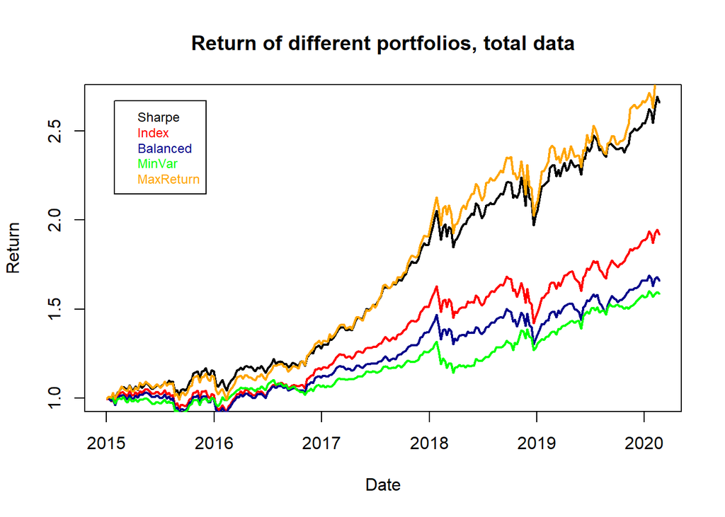

```r
# total dataset
plot(as.Date(rownames(myDataTotal)),cumprod(1 + portReturns(optiWeights,myData = myDataTotal)),type="l",lwd=2, col="black",
     xlab="Date",ylab="Return",main="Return of different portfolios, total data")
lines(as.Date(rownames(myDataTotal)),cumprod(1 + portReturns(orgWeights,myData = myDataTotal)),type="l",lwd=2, col="red")
lines(as.Date(rownames(myDataTotal)),cumprod(1 + portReturns(balWeights,myData = myDataTotal)),type="l",lwd=2, col="darkblue")
lines(as.Date(rownames(myDataTotal)),cumprod(1 + portReturns(minWeights,myData = myDataTotal)),type="l",lwd=2, col="green")
lines(as.Date(rownames(myDataTotal)),cumprod(1 + portReturns(maxWeights,myData = myDataTotal)),type="l",lwd=2, col="orange")
legend("topleft",inset = .05,legend = c("Sharpe","Index","Balanced","MinVar","MaxReturn"),
       text.col = c("black","red","darkblue","green","orange"),cex=0.75)
```

# Efficent Frontiers

Now calculating the risk/return ratio and plot all portfolios on mean-variance plot. Get the Efficent frontier from “fPortfolio”, train and test dataset:

[figure not shown]

```r
# calculate & plot efficient frontier
PlotEff = function(myDataSource){
  effFrontier = portfolioFrontier(as.timeSeries(myDataSource), constraints = "LongOnly")
  plot(effFrontier,c(1)) # c(1,2,5)
  points(x=portRisk(optiWeights,myData = myDataSource)/length(portRisk(optiWeights,myData = myDataSource)),
         y=sum(portReturns(optiWeights,myData = myDataSource)/length(portReturns(optiWeights,myData = myDataSource))),
         col="black",pch=8,cex=1)
  points(x=portRisk(orgWeights,myData = myDataSource)/length(portRisk(orgWeights,myData = myDataSource)),
         y=sum(portReturns(orgWeights,myData = myDataSource)/length(portReturns(orgWeights,myData = myDataSource))),
         col="red",pch=16,cex=1)
  points(x=portRisk(balWeights,myData = myDataSource)/length(portRisk(balWeights,myData = myDataSource)),
         y=sum(portReturns(balWeights,myData = myDataSource)/length(portReturns(balWeights,myData = myDataSource))),
         col="darkblue",pch=16,cex=1)
  points(x=portRisk(minWeights,myData = myDataSource)/length(portRisk(minWeights,myData = myDataSource)),
         y=sum(portReturns(minWeights,myData = myDataSource)/length(portReturns(minWeights,myData = myDataSource))),
         col="green",pch=16,cex=1)
  points(x=portRisk(maxWeights,myData = myDataSource)/length(portRisk(maxWeights,myData = myDataSource)),
         y=sum(portReturns(maxWeights,myData = myDataSource)/length(portReturns(maxWeights,myData = myDataSource))),
         col="orange",pch=16,cex=1)
  legend("right",title = deparse(substitute(myDataSource)), legend = c("Sharpe","Index","Balanced","MinVar","MaxReturn"), bty = "n",
         lwd = 1, cex = 0.75, col = c("black","red","darkblue","green","orange"), lty = c(rep(NA,5)), pch = c(8, rep(16,4)))
}
#select dataset
PlotEff(myDataSource = myData)
```

[figure not shown]

```r
PlotEff(myDataSource = myDataFuture)
```

At least for the train data, the results approx. match with the results of fPortfolio: MinVar Portfolio is very close to where it belongs, the Sharpe Portfolio lies close to the Efficent frontier. The MaxRetrun PF has the highest risk. The Ga seems to generate reasonable results!!! Since predicting future stock prices includes a vast of other factors than just chosing the “right” weights, the results are not contrary to the assumption that overall, the Ga does a decent work.

## Risk/Return tables

Finally, see all values in the tables below:

```r
# train & test datasets

DataFrameEff = function(myDataSource){
  Riskmeasures = c(portRisk(optiWeights,myData = myDataSource),
                   portRisk(orgWeights,myData = myDataSource),
                   portRisk(balWeights,myData = myDataSource),
                   portRisk(minWeights,myData = myDataSource),
                   portRisk(maxWeights,myData = myDataSource))
  Returnmeasures = c(sum(portReturns(optiWeights,myData = myDataSource)),
                     sum(portReturns(orgWeights,myData = myDataSource)),
                     sum(portReturns(balWeights,myData = myDataSource)),
                     sum(portReturns(minWeights,myData = myDataSource)),
                     sum(portReturns(maxWeights,myData = myDataSource)))

  data.frame("PF" = c("Sharpe","Index","Balanced","MinVar","MaxReturn"), "Risk - total" = Riskmeasures, "Return - total" = Returnmeasures,
             stringsAsFactors = FALSE)
}

kable(DataFrameEff(myDataSource = myData), caption = "Train dataset")
```

Train dataset

| PF | Risk…total | Return…total |
| --- | --- | --- |
| Sharpe | 0.0188691 | 0.8371979 |
| Index | 0.0187789 | 0.5033410 |
| Balanced | 0.0181214 | 0.3966994 |
| MinVar | 0.0154057 | 0.3210257 |
| MaxReturn | 0.0212709 | 0.8946874 |

```r
kable(DataFrameEff(myDataSource = myDataFuture), caption = "Test dataset")
```

Test dataset

| PF | Risk…total | Return…total |
| --- | --- | --- |
| Sharpe | 0.0156412 | 0.1872014 |
| Index | 0.0154192 | 0.1941795 |
| Balanced | 0.0155268 | 0.1509266 |
| MinVar | 0.0122741 | 0.1704797 |
| MaxReturn | 0.0184463 | 0.1823576 |